# TP3_logistic_regression

## TP3 : Logistic regression

The purpose of this tutorial is to implement and use the Logistic Regression for binary classification. We will apply this method to the problem of handwritten characters to learn how to distinguish two numbers (here 5 and 6).

```python
from pylab import *
import numpy as np
import matplotlib.pyplot as plt
import seaborn as sns

from numpy import linalg as la
from sklearn.metrics import confusion_matrix
from sklearn.model_selection import train_test_split
from matplotlib import colors
from scipy import linalg
```

## 1. Logistic regression, IRLS algorithm.

### Preliminary question: the algorithm

#### Have a look at the function `regression_logistique.m` and locate the main steps of the algorithm you have been taught (see course).

You can comment the code in the cell below.

```python
def regression_logistique(X,t,Nitermax=20,eps_conv=1e-3):
    '''Entrees :
    X = [ones(N_train,1) x_train];
    t = class_train
    Nitermax = nombre maximale d'itérations (20 par défaut)
    eps_conv = critère de convergence sur norm(w-w_old)/norm(w) ;
    eps_conv=1e-3 par défaut

    Sorties :
    w : vecteur des coefficients de régression logistique
   Niter : nombre d'itérations utilisées effectivement

   Fonction de régression logistique pour la classification binaire.

   Utilisation :
       Nitermax = 50
       eps_conv = 1e-4
       [w,Niter] = regression_logistique(X,t,Nitermax,eps_conv)
    '''
    N_train = X.shape[0]

    #initialisation : 1 pas de l'algorithme IRLS
    w = np.zeros((X.shape[1],))
    w_old = w
    y = 1/2*np.ones((N_train,))
    R = np.diag(y*(1-y))   # diag(y_n(1-y_n))
    z = X.dot(w_old)-la.inv(R).dot(y-t)
    w = la.inv(X.T.dot(R).dot(X)).dot(X.T).dot(R).dot(z)

    # boucle appliquant l'algortihme de Newton-Raphson
    Niter = 1
    while ( (la.norm(w-w_old)/la.norm(w)>eps_conv) | (Niter<Nitermax) ):
        Niter = Niter+1
        y = 1/(1+np.exp(-X.dot(w))) # Apply sigmoid function to XwT
        R = np.diag(y*(1-y)) # construction of the diagonal matrix y(1-y)
        w_old = w
        z = X.dot(w_old)-la.inv(R).dot(y-t) # calculate z using old values of w
        w = la.inv(X.T.dot(R).dot(X)).dot(X.T).dot(R).dot(z) # calcul new w

    return w, Niter
```

### Reading & preparing synthetic data

Load the training and test data sets `synth_train.txt` and `synth_test.txt`. The targets t belong to {1,2} and the features  
x belong to R^2.

We have 100 training samples and 200 test samples

- the 1st column contains the label of each sample,
- columns 2 and 3 contain the coordinate of each point.

```python
# Training set
synth_train = np.loadtxt('synth_train.txt')
class_train = synth_train[:,0]
class_train_1 = np.where(synth_train[:,0]==1)[0]
class_train_2 = np.where(synth_train[:,0]==2)[0]
x_train = synth_train[:,1:]
N_train = np.size(x_train,axis=0)

# Test set
synth_test = np.loadtxt('synth_test.txt')
class_test = synth_test[:,0]
class_test_1 = np.where(synth_test[:,0]==1)[0]
class_test_2 = np.where(synth_test[:,0]==2)[0]
x_test = synth_test[:,1:]
N_test = np.size(x_test,axis=0)
```

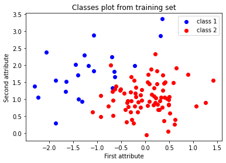

```python
plt.figure(figsize=(6, 4), facecolor='white')
plt.scatter(x_train[class_train_1][:,0], x_train[class_train_1][:,1], color="b", label="class 1")
plt.scatter(x_train[class_train_2][:,0], x_train[class_train_2][:,1], color="r", label="class 2")
plt.xlabel("First attribute")
plt.ylabel("Second attribute")
plt.legend()
plt.title("Classes plot from training set")
plt.show()
```

The classes seem linearly separable, without outliers or observations far from the decision line. We expect however to have few misclassifications given those near the decision line.

### Preparing features for logistic regression (binary classification)

First, we prepare the feature matrix and the target vector associated to the training and test sets:

```python
X = np.hstack((np.ones((N_train,1)),x_train))
t = 2-class_train   # 0 if class=2, 1 if class=1

X_test = np.hstack((np.ones((N_test,1)),x_test))
t_test = 2-class_test   # 0 if class=2, 1 if class=1
```

### Exercise 1 : the logistic function of decision

1. Use the function `regression_logistique.m` to estimate the logistic regression vector `w`. Indication : use

   ```
   Nitermax = 50;
   eps_conv=1e-3;
   ```

   .
2. Compute the decision function $f(x) = argmax_k P(C_k|x)$ on the test set to get the classification results. Recall that $y_n=\sigma(w^T x)$ (logistic function) and that *using vectors* you may directly write $y=\sigma(Xw)$, with the column of ones in X.
3. Display the results by plotting the points from both the training set and the test set.
4. Write the equation which defines the decision boundary.
5. Artificially add a few points to the training set far from the decision boundary to check the robustness of logistic regression to outliers. Check the behaviour of LDA for comparison in this case and comment.

```python
#Exercise 1
w, Niter = regression_logistique(X, t, Nitermax=50, eps_conv=1e-3)
print("final coefficients: ", w)
sigmoid = lambda x : 1/(1 + np.exp(-x))
decision = lambda x, w: argmax([1 - sigmoid(np.dot(x, w.T)), sigmoid(np.dot(x, w.T))], axis=0)
def error(pred, truth):
    """Calculate the average error"""
    return (np.sum([pred != truth]))/truth.shape[0]
```

```
final coefficients:  [-15.206658    -7.91866363   6.56243114]
```

You can draw the decision boundary $w^Tx = 0$ by using:

[figure not shown]

```python
pred = decision(X_test, w)
pred = np.array(pred)
plt.figure(figsize=(6, 4), facecolor='white')
x1 = np.linspace(-2.5,1.5,10)
x2 = (-w[0]-w[1]*x1)/w[2]
plt.plot(x1,x2,'k--')
# plot the right predictions and the misclassified
plt.scatter(X_test[np.where((pred==0) & (t_test==0)),1], X_test[np.where((pred==0) & (t_test==0)),2], color="b", label="class 1")
plt.scatter(X_test[np.where((pred==1) & (t_test==1)),1], X_test[np.where((pred==1) & (t_test==1)),2], color="r", label="class 2")
plt.scatter(X_test[np.where(pred - t_test !=0),1], X_test[np.where(pred - t_test !=0),2], color="black", label="Misclassified")

plt.xlabel("First attribute")
plt.ylabel("Second attribute")
plt.legend()
plt.title("Classes predicted from training set")
plt.show()
```

As said previously, we have few misclassifications given the points near the decision line.

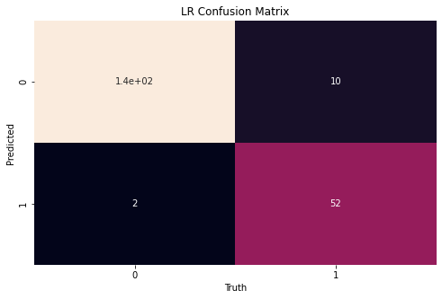

```python
pred_test = decision(X_test, w)
cm = confusion_matrix(pred_test, t_test)
tn, fp, fn, tp = cm.ravel()
plt.figure(figsize=(8, 5), facecolor='white')
plt.title("LR Confusion Matrix")
sns.heatmap(cm, annot=True, cbar=False)
plt.xlabel("Truth")
plt.ylabel("Predicted")
plt.show()
```

We have a difficulty predicting the minority class (class 1) and this is a common problem for logistic regression models, we might want to augmentate the data (oversample it) and undersample it. The logistic regression models are usually more robust on larger data set, so undersampling the set will decrease the performance.

```python
precision_lr = tp / (tp + fp)
recall_lr = tp / (tp + fn)
F1_lr = 2 * (precision_lr * recall_lr) / (precision_lr + recall_lr)
mcc_lr = (tp*tn - fp*fn)/ sqrt((tp+fp)*(tp+fn)*(tn+fp)*(tn+fn))
print(f"The precision of LR = {round(precision_lr, 4)}")
print(f"The recall of LR = {round(recall_lr, 4)}")
print(f"The F1 of LR = {round(F1_lr, 4)}")
print(f"The MCC score of LR = {round(mcc_lr, 4)}")
```

```
The precision of LR = 0.8387
The recall of LR = 0.963
The F1 of LR = 0.8966
The MCC score of LR = 0.8586
```

Here, we have a good recall so the classifier returns most of the relevant results: it means that it classify well the two classes.

On the decision boundary, the output of $\sigma(w^Tx_n)=0.5$

So $w^Tx_n=0$

$w^T$ $x$ = 0 $\Leftrightarrow$ $w_{0} + w_{1}x_{1} + w_{2}x_{2}$ = 0 $\Leftrightarrow$ $x_{2}$ = $-\frac{w_{0}}{w_{2}}$ $-\frac{w_{1}}{w_{2}}$ $x_{1}$

```python
a = -w[1]/w[2]
b = -w[0]/w[2]

print(f"The decision boundary equation : y = {round(a,2)} x + {round(b,2)}")
```

```
The decision boundary equation : y = 1.21 x + 2.32
```

### Logistic regression with outliers

Here we will apply our model on a data that contains outliers. They should be easier to classify as they are fare from the decision boundary, but this would mean that in our diagonal matrix containing the y(1 -y) there will be zeros, so the matrix might not be inversible

```python
def regression_logistique_not_inv_R(X,t,Nitermax=20,eps_conv=1e-3, out=False):
    '''Entrees :
    X = [ones(N_train,1) x_train];
    t = class_train
    Nitermax = nombre maximale d'itérations (20 par défaut)
    eps_conv = critère de convergence sur norm(w-w_old)/norm(w) ;
    eps_conv=1e-3 par défaut

    Sorties :
    w : vecteur des coefficients de régression logistique
   Niter : nombre d'itérations utilisées effectivement

   Fonction de régression logistique pour la classification binaire.

   Utilisation :
       Nitermax = 50
       eps_conv = 1e-4
       [w,Niter] = regression_logistique(X,t,Nitermax,eps_conv)
    '''
    N_train = X.shape[0]

    #initialisation : 1 pas de l'algorithme IRLS
    w = np.zeros((X.shape[1],))
    w_old = w
    y = 1/2*np.ones((N_train,))
    R = np.diag(y*(1-y))  # diag(y_n(1-y_n))
    z = X.dot(w_old)-la.inv(R).dot(y-t)

    w = la.inv(X.T.dot(R).dot(X)).dot(X.T).dot(R).dot(z)

    # boucle appliquant l'algortihme de Newton-Raphson
    Niter = 1
    while ( (la.norm(w-w_old)/la.norm(w)>eps_conv) | (Niter<Nitermax) ):
        Niter = Niter+1
        y = 1/(1+np.exp(-X.dot(w)))
        R = np.diag(y*(1-y))
        w_old = w
        try: # if the R is not inversible, we stop
            inv_R = la.inv(R)
        except:
            if out:
                print(f" R is not inversible after {Niter}")

            break
        z = X.dot(w_old)-inv_R .dot(y-t)
        w = la.inv(X.T.dot(R).dot(X)).dot(X.T).dot(R).dot(z)

    return w, Niter
```

```python
np.random.seed(10)
N_add_1, N_add_2 = 100,100
sigma_1 = (0.1, 0.5)
sigma_2 = (0.5, 0.1)

x_far_1 = np.array([-2,4]) + np.random.normal(scale=sigma_1, size=(N_add_1,2))
X_far_1 = np.hstack((np.ones((N_add_1,1)), x_far_1))
t_far_1 = np.ones((1,N_add_1))[0]

x_far_2 = np.array([1,0]) + np.random.normal(scale=sigma_2, size=(N_add_2,2))
X_far_2 = np.hstack((np.ones((N_add_2,1)),x_far_2))
t_far_2 = np.zeros((1,N_add_2))[0]

x_far = np.concatenate([x_far_1,x_far_2])
X_far = np.concatenate([X_far_1,X_far_2])
t_far = np.concatenate([t_far_1,t_far_2])

x_train_new = np.concatenate([x_train,x_far])
X_new = np.concatenate([X,X_far])

class_train_new = np.concatenate([t,t_far])

t_new = 2 - class_train_new
w_out, Niter = regression_logistique_not_inv_R(X_new, t_new, out=True)
pred_new = decision(X_new, w_out)
print("final coefficients: ", w)
```

```
 R is not inversible after 3
final coefficients:  [-15.206658    -7.91866363   6.56243114]
```

```python
print("error on the training set with outliers: ", round(error(pred_new, t_new), 4))
print("error on the test set with outliers: ", error(decision(X_test, w_out), t_test))
```

```
error on the training set with outliers:  0.7667
error on the test set with outliers:  0.72
```

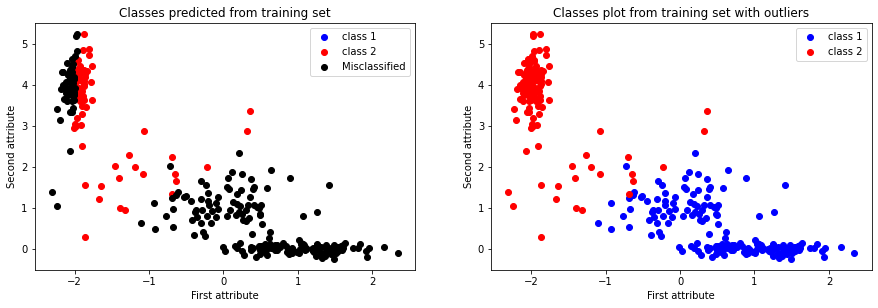

```python
pred_out = decision(X_new, w_out)
plt.figure(figsize=(15, 10), facecolor='white')
# plot the prediction on the new data with outliers
plt.subplot(2, 2, 1)
plt.scatter(X_new[np.where((pred_out==0) & (t_new==0)),1], X_new[np.where((pred_out==0) & (t_new==0)),2], color="b", label="class 1")
plt.scatter(X_new[np.where((pred_out==1) & (t_new==1)),1], X_new[np.where((pred_out==1) & (t_new==1)),2], color="r", label="class 2")
plt.scatter(X_new[np.where(pred_out - t_new !=0),1], X_new[np.where(pred_out - t_new !=0),2], color="black", label="Misclassified")
plt.xlabel("First attribute")
plt.ylabel("Second attribute")
plt.legend()
plt.title("Classes predicted from training set")

# plot the new data with outliers
plt.subplot(2, 2, 2)
x1 = np.linspace(-2.5,2.5,10)
x2 = (-w[0]-w[1]*x1)/w[2]
class_train_1_n = np.where(class_train_new==0)[0]
class_train_2_n = np.where(class_train_new==1)[0]
plt.scatter(x_train_new[class_train_1_n][:,0], x_train_new[class_train_1_n][:,1], color="b", label="class 1")
plt.scatter(x_train_new[class_train_2_n][:,0], x_train_new[class_train_2_n][:,1], color="r", label="class 2")
plt.xlabel("First attribute")
plt.ylabel("Second attribute")
plt.legend()
plt.title("Classes plot from training set with outliers")
plt.show()
```

Class 2 contains mostly element whose first feature coordinate is negative, which means $-w_1x_{k,1}$ in the probability expression for class 1 will make it so that $P(x_k \in C1)$ converges to 0, but we should have the opposite effect with elements of class 1 (positive first coordinate) which is not the case and that might be due to the intercept that is overset.

Logistic Regression models are not much impacted due to the presence of outliers because the sigmoid function tapers the outliers. But the presence of extreme outliers may somehow affect the performance of the model and lowering the performance. In general, when we have extreme outliers and we want to use Logistic regression, we have to remove these points. The idea of removing the extreme misclassified data points are being implemented in the following steps:

1. Train a logistic regression model for a given dataset
2. Compute the weight vector for the model trained in step 1. In scikit-learn, the weight vector can be computed using classifier.coef_.
3. Compute the distance of each of the data points from the weight vector.
4. Decide a distance threshold, to remove the extreme data points.
5. Remove the data points having a distance greater than the decided threshold.
6. Re-train the same logistic regression model on the new data from step 5.

### Adjusting the classification threshold

We have two times the number of obersavtions belonging to class 2 than to class 1, and this affect the calculations of the intercept in our Logistic model. One way to counter this problem, is to apply a weighted class intercept, as implemented in scikit-learn, and we will explore this part afterwards. Another way is to adjust the classification threshold, up to now we took the maximum of probabilities. That is to say we compared probabilities to 0.5. However, and especially in imbalanced cases, a different threshold might work better, by helping the classification of the minority class.

In this part, we will take a look at the probability distribution and plot the ROC curve to get the best threshold (maximizing the G-mean score, $g-mean = \sqrt{TPR*(1-FPR)}$)

```python
unique, counts = np.unique(class_test, return_counts=True)
print(f"The balance of the test data {dict(zip(unique, counts))}")
```

```
The balance of the test data {1.0: 62, 2.0: 138}
```

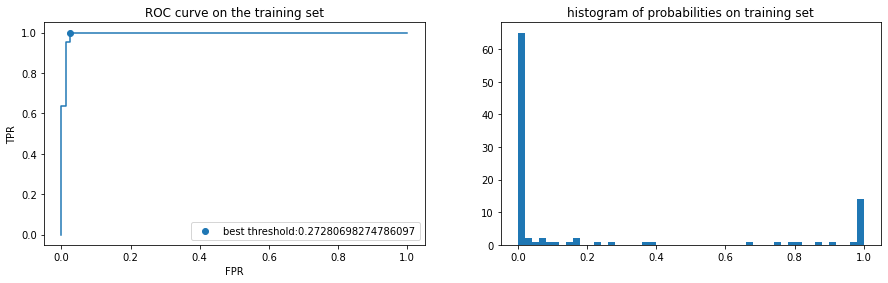

```python
from sklearn.metrics import roc_curve

w, _ = regression_logistique(X, t)
pred_proba = sigmoid(np.dot(X, w.T))
fpr, tpr, thresholds = roc_curve(t, pred_proba)
best_thres = np.argmax(np.sqrt(tpr * (1 - fpr)))
plt.figure(figsize=(15, 9), facecolor="white")
plt.subplot(2, 2, 1)
plt.plot(fpr, tpr)
plt.xlabel("FPR")
plt.ylabel("TPR")
plt.title("ROC curve on the training set")
plt.scatter(fpr[best_thres], tpr[best_thres], label=f"best threshold:{thresholds[round(best_thres, 4)]}")
plt.legend()
plt.subplot(2, 2, 2)
plt.hist(pred_proba, bins = 50)
plt.title("histogram of probabilities on training set")
plt.show()
```

Most probabilities are distributed around 0 given the class imbalance, so it makes sense that the best threshold we be lower than 0.5, and in this case 0.27. Usually theROC curve could be optimistic and doesn't take into account the performance on the minority class. We will use the F1-MCC curve that is more suitable for imbalanced data such as ours [4], the best threshold will be the closest to the point (1, 1):

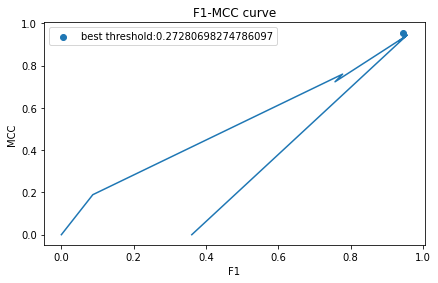

```python
from sklearn.metrics import f1_score, matthews_corrcoef, roc_curve
# function to compare the probabilities with a threshold given as an argument
decision_thres = lambda x, thres: np.array([thres<=sigmoid(np.dot(x, w.T))]).astype(int)

F1 = np.zeros(len(thresholds))
MCC = np.zeros(len(thresholds))
# in order not to store a matrix of prediction for each threshold,
# we'll iterate over the thresholds
for idx, thres in enumerate(thresholds):
    y_pred = decision_thres(X, thres).reshape(t.shape)
    F1[idx] = f1_score(t, y_pred)
    MCC[idx] = matthews_corrcoef(t, y_pred)
best = np.array([1, 1])
best_thres = np.argmin([la.norm(best -x) for x in np.hstack((F1, MCC))])
plt.figure(figsize=(15, 9), facecolor="white")
plt.subplot(2, 2, 1)
plt.plot(F1, MCC)
plt.xlabel("F1")
plt.ylabel("MCC")
plt.title("F1-MCC curve")
plt.scatter(MCC[best_thres], F1[best_thres], label=f"best threshold:{thresholds[round(best_thres, 4)]}")
plt.legend()
plt.show()
```

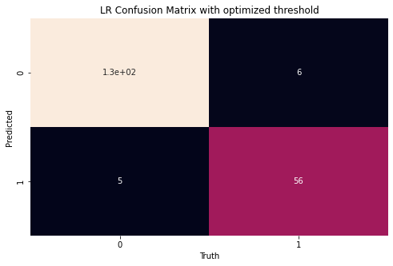

```python
y_pred = decision_thres(X_test, 0.273).reshape(t_test.shape)
cm = confusion_matrix(y_pred, t_test)
tn, fp, fn, tp = cm.ravel()
plt.figure(figsize=(8, 5), facecolor='white')
plt.title("LR Confusion Matrix with optimized threshold")

sns.heatmap(cm, annot=True, cbar=False)
plt.xlabel("Truth")
plt.ylabel("Predicted")
plt.show()
```

The confusion matrix plots the decision on the test set. We have better classification on the class 1 than before (here class 1), as opposed to the classification of class 2 (0), which makes sense because we allowed more instances o be considered True. In our case, F1-MCC curve and the ROC curve have given similar best thresholds, we won't need to weight their outputs in order to find the best one.

### Final scores

```python
precision_lr = tp / (tp + fp)
recall_lr = tp / (tp + fn)
F1_lr = 2 * (precision_lr * recall_lr) / (precision_lr + recall_lr)
mcc_lr = (tp*tn - fp*fn)/ sqrt((tp+fp)*(tp+fn)*(tn+fp)*(tn+fn))
print(f"The precision of LR = {round(precision_lr, 4)}")
print(f"The recall of LR = {round(recall_lr, 4)}")
print(f"The F1 of LR = {round(F1_lr, 4)}")
print(f"The MCC score of LR = {round(mcc_lr, 4)}")
```

```
The precision of LR = 0.9032
The recall of LR = 0.918
The F1 of LR = 0.9106
The MCC score of LR = 0.8709
```

We can conclude that the Logistic regression works really well in this situation and we won't need to go for more complex non-linear models.

### Comparing the results to LDA model

In this part we will compare our Logistic model to an LDA model, with wand without the outliers addition. As we know, the LDA takes into account the whole distribution of the data so it might be affect by the presence of points far from the normal distribution it expect it to be.

```python
from sklearn.discriminant_analysis import LinearDiscriminantAnalysis

LinearClassifier = LinearDiscriminantAnalysis(store_covariance=True)
LinearClassifier.fit(X=x_train,y=t)

LinearClassifier_new = LinearDiscriminantAnalysis(store_covariance=True)
LinearClassifier_new.fit(X=x_train_new, y=t_new)


t_test_pred_without_outliers = LinearClassifier.predict(x_test)
test_error_without_outliers = error(t_test_pred_without_outliers,t_test)

t_test_pred_with_outliers = LinearClassifier_new.predict(x_test)
test_error_with_outliers = error(t_test_pred_with_outliers,t_test)

print(f"Test error without outliers = {test_error_without_outliers}")
print(f"Test error with outliers = {test_error_with_outliers}")
```

```
Test error without outliers = 0.055
Test error with outliers = 0.775
```

#### Function to plot LDA

Extracted from the sk-learn documentation [5]

```python
cmap = colors.LinearSegmentedColormap(
    "red_blue_classes",
    {
        "red": [(0, 1, 1), (1, 0.7, 0.7)],
        "green": [(0, 0.7, 0.7), (1, 0.7, 0.7)],
        "blue": [(0, 0.7, 0.7), (1, 1, 1)],
    },
)
plt.cm.register_cmap(cmap=cmap)
```

```python
def plot_data(lda, X, y, y_pred, fig_index):
    splot = plt.subplot(2, 2, fig_index)
    if fig_index == 1:
        plt.title("Linear Discriminant Analysis")
        plt.ylabel("Data with\n fixed covariance")
    elif fig_index == 3:
        plt.ylabel("Data with\n varying covariances")

    tp = y == y_pred  # True Positive
    tp0, tp1 = tp[y == 0], tp[y == 1]
    X0, X1 = X[y == 0], X[y == 1]
    X0_tp, X0_fp = X0[tp0], X0[~tp0]
    X1_tp, X1_fp = X1[tp1], X1[~tp1]

    # class 0: dots
    plt.scatter(X0_tp[:, 0], X0_tp[:, 1], marker=".", color="red")
    plt.scatter(X0_fp[:, 0], X0_fp[:, 1], marker="x", s=20, color="#990000")  # dark red

    # class 1: dots
    plt.scatter(X1_tp[:, 0], X1_tp[:, 1], marker=".", color="blue")
    plt.scatter(
        X1_fp[:, 0], X1_fp[:, 1], marker="x", s=20, color="#000099"
    )  # dark blue

    # class 0 and 1 : areas
    nx, ny = 200, 100
    x_min, x_max = plt.xlim()
    y_min, y_max = plt.ylim()
    xx, yy = np.meshgrid(np.linspace(x_min, x_max, nx), np.linspace(y_min, y_max, ny))
    Z = lda.predict_proba(np.c_[xx.ravel(), yy.ravel()])
    Z = Z[:, 1].reshape(xx.shape)
    plt.pcolormesh(
        xx, yy, Z, cmap="red_blue_classes", norm=colors.Normalize(0.0, 1.0), zorder=0, shading='auto'
    )
    plt.contour(xx, yy, Z, [0.5], linewidths=2.0, colors="white")

    # means
    plt.plot(
        lda.means_[0][0],
        lda.means_[0][1],
        "*",
        color="yellow",
        markersize=15,
        markeredgecolor="grey",
    )
    plt.plot(
        lda.means_[1][0],
        lda.means_[1][1],
        "*",
        color="yellow",
        markersize=15,
        markeredgecolor="grey",
    )

    return splot


def plot_ellipse(splot, mean, cov, color):
    v, w = linalg.eigh(cov)
    u = w[0] / linalg.norm(w[0])
    angle = np.arctan(u[1] / u[0])
    angle = 180 * angle / np.pi  # convert to degrees
    # filled Gaussian at 2 standard deviation
    ell = mpl.patches.Ellipse(
        mean,
        2 * v[0] ** 0.5,
        2 * v[1] ** 0.5,
        180 + angle,
        facecolor=color,
        edgecolor="black",
        linewidth=2,
    )
    ell.set_clip_box(splot.bbox)
    ell.set_alpha(0.2)
    splot.add_artist(ell)
    splot.set_xticks(())
    splot.set_yticks(())


def plot_lda_cov(lda, splot):
    plot_ellipse(splot, lda.means_[0], lda.covariance_, "red")
    plot_ellipse(splot, lda.means_[1], lda.covariance_, "blue")
```

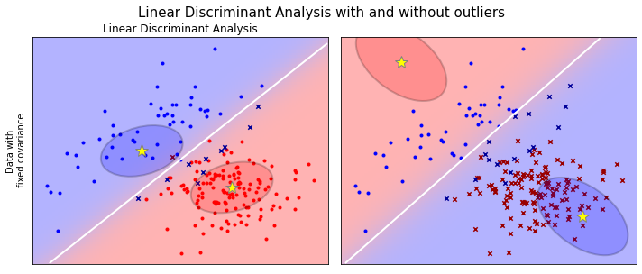

```python
i = 0
plt.figure(figsize=(10, 8), facecolor="white")
plt.suptitle(
    "Linear Discriminant Analysis with and without outliers",
    y=0.98,
    fontsize=15,
)

# Linear Discriminant Analysis without ourliers
splot = plot_data(LinearClassifier, x_test, t_test, t_test_pred_without_outliers, fig_index=1)
plot_lda_cov(LinearClassifier, splot)
plt.axis("tight")
# Linear Discriminant Analysis with ourliers

splot = plot_data(LinearClassifier_new, x_test, t_test, t_test_pred_with_outliers, fig_index=2)
plot_lda_cov(LinearClassifier_new, splot)
plt.axis("tight")
plt.tight_layout()
plt.subplots_adjust(top=0.92)
plt.show()
```

We have to deal with outliers before using LDA in order to have a good classifier.

```python
cm = confusion_matrix(t_test_pred_without_outliers, t_test)
tn, fp, fn, tp = cm.ravel()
precision_lr = tp / (tp + fp)
recall_lr = tp / (tp + fn)
F1_lr = 2 * (precision_lr * recall_lr) / (precision_lr + recall_lr)
mcc_lr = (tp*tn - fp*fn)/ sqrt((tp+fp)*(tp+fn)*(tn+fp)*(tn+fn))
print(f"The precision of LDA = {round(precision_lr, 4)}")
print(f"The recall of LDA = {round(recall_lr, 4)}")
print(f"The F1 of LDA = {round(F1_lr, 4)}")
print(f"The MCC score of LDA = {round(mcc_lr, 4)}")
```

```
The precision of LDA = 0.8387
The recall of LDA = 0.9811
The F1 of LDA = 0.9043
The MCC score of LDA = 0.8713
```

Just like the previous work, we could change the representation of the data to $\phi(X)$ so that it is linearly separable.

We can use more robust algorithm that can handle outliers such as RLDA, one-step M-estimator (MOM) and winsorized one-step M-estimator (WMOM) to alleviate the classification problem. These two robust estimators(MOM and WMOM) used trimming and winsorizing approach to eliminate the outliers of the data and then form the robust discriminant rule. Their function as the substitutes for the classical estimators in Linear Discriminant Analysis (LDA) model very much improves the misclassification rates.[1]

## 2. Application: handwritten digits recognition 5 & 6

We load 2 matrices which contain each a sequence of examples of 16x16 images of handwritten digits which are 5 and 6 here. Each line of the matrix contains 256 pixel values coding for the gray level of a 16x16 image.

```python
train_5 = np.loadtxt('train_5.txt',delimiter=',')   # 556 samples
train_6 = np.loadtxt('train_6.txt',delimiter=',')   # 664 samples
```

### Examples of images

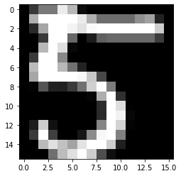

```python
# Digit 5
n=9;
I = np.reshape(train_5[n,:],(16,16))

plt.imshow(I,cmap='gray')
plt.show()
```

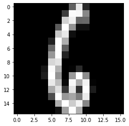

```python
# Digit 6
n=5;
I = reshape(train_6[n,:],(16,16))

plt.imshow(I,cmap='gray')
plt.show()
```

### Separating the training and test sets

We keep in the training set the 145 first images of 5s and the 200 first images of 6s:

```python
x_train_brut = np.vstack((train_5[:145,:], train_6[:200,:]))
N_train = np.size(x_train_brut,axis=0)
class_train = np.ones(345)   # label 1 for digit 6
class_train[:145] = 0       # label 0 for digit 5

x_test_brut = np.vstack((train_5[145:,:], train_6[200:,:]))
N_test = np.size(train_5,axis=0)+np.size(train_6,axis=0)-N_train
class_test = np.ones(train_5[145:,:].shape[0] + train_6[200:,:].shape[0])   # label 1 for digit 6
class_test[:train_5[145:,:].shape[0]] = 0       # label 0 for digit 5
```

## Exercise 2: logistic regression to classify 5 & 6

1. Note that pixel values are between -1 and 1 by using the functions `min(I(:))` and `max(I(:))`.
2. Identify the indices of the most significant pixels, which are defined as having a standard deviation greater than 0.5 here. We denote by `lis_sig` the list of positions of these significant pixels in the image vector. _Indication : the function `std` gives the standard deviation (columnwise in matrices) and you should find 173 pixel positions.
3. Show a binary image to locate these pixels. _Indication : `Isig = zeros(16); Isig(list_sig)=1; Isig=Isig';`._
4. Define the training set `x_train` from `x_train_brut` from the significant pixels only.
5. Do the same with `x_test_brut` to extract `x_test`.
6. Use `regression_logistique.m` to estimate the logistic regression vector `w` from the training set `x_train`. Choose `Nitermax = 13; eps_conv = 1e-3;`
7. Compute the decision function and the labels of the test set `x_test`. *Indication : do not forget the column of ones !*
8. Estimate the classification error rate by using : `erreur = sum(abs(class-class_test))/N_test;`.
9. Locate some misclassified examples and visualize the corresponding image. Comment on your results and observations.

First we will shuffle the data as all the first elements are 5 and the rest is 6, and this might bias the model.

```python
# Exercise 2
from sklearn.utils import shuffle
x_train_brut, class_train = shuffle(x_train_brut, class_train, random_state=0)
x_test_brut, class_test = shuffle(x_test_brut, class_test, random_state=0)
std = np.std(x_train_brut, axis=0)
list_sig = np.where(std > 0.5)[0]
```

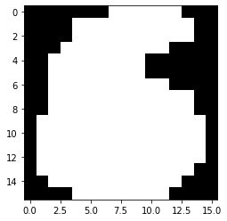

```python
Isig = np.zeros(x_train_brut.shape[1])
Isig[list_sig] = 1
Isig = Isig.reshape((16, 16))

plt.imshow(Isig, cmap='gray')
plt.show()
```

```python
# Define the training set
x_train = x_train_brut[:, list_sig]
x_test = x_test_brut[:, list_sig]
X_train = np.hstack((np.ones((N_train,1)),x_train))
X_test = np.hstack((np.ones((x_test.shape[0],1)),x_test))
```

```python
w, Niter = regression_logistique_not_inv_R(X_train, class_train, 20, 1e-3, out=True)
# Calculate y_pred on train set
y_pred_train = decision(X_train, w)
# Calculate y_pred on test set
y_pred_test = decision(X_test, w)
```

```
 R is not inversible after 15
```

Here again the matrix R is no longer inversible after 15 iterations, which suggests that some images are quite distinct and far from the decision boundary. The other situation would be that some features in the training set are colinear, but that would mean that the logistic regression function would stop at the very begining, which is not the case.

```python
print("train error: ", error(y_pred_train, class_train))
print("test error: ", error(y_pred_test, class_test))
```

```
train error:  0.0
test error:  0.07885714285714286
```

[figure not shown]

```python
cm = confusion_matrix(y_pred_test, class_test)
tn, fp, fn, tp = cm.ravel()
plt.figure(figsize=(8, 5), facecolor='white')
plt.title("LDA Confusion Matrix")
sns.heatmap(cm, annot=True, cbar=False)
plt.xlabel("Truth")
plt.ylabel("Predicted")
plt.show()
```

### Study misclassified instances

We will take a random misclassified instance, and see why the model made that decision

```python
false_ind = np.where(y_pred_test != class_test)[0]
x_test_false = x_test[false_ind, :]
```

```
original class 5.0
predicted class 6
```

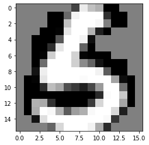

```python
np.random.seed(1050)
n = np.random.choice(false_ind)
# label 1 for digit 6
# label 0 for digit 5
print(f"original class {5 + class_test[n]}")
print(f"predicted class {5 + y_pred_test[n]}")

Isig = np.zeros(x_test_brut.shape[1])
Isig[list_sig] = x_test[n,:]
Isig = Isig.reshape((16, 16))

plt.imshow(Isig, cmap='gray')
plt.show()
```

In some cases, the original picture looks very similar to the predicted class (e.g looks like a 6 when it's a five), it is possible that the data set contains some instances that are not correct. In black we can see that thresholding it, made it seem more like a six than a five, so we will attempt to tune the model on this parameter:

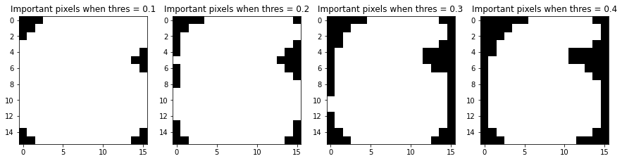

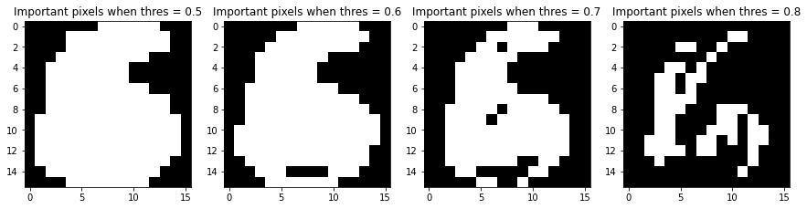

```python
threshold_list = [i * 0.1 for i in range(1, 9)]
std = np.std(x_train_brut, axis=0)
Niter_list = []
train_error_list = []
test_error_list = []
nstepplot = 1
nplot_per_row = 4
plotpos = 0
for step, threshold in enumerate(threshold_list):
    std = np.std(x_train_brut, axis=0)
    list_sig = np.where(std > threshold)[0]
    if not step%nstepplot:
        if not plotpos: plt.figure(figsize=(15,4), facecolor="white")
        plotpos+=1
        plt.subplot(1,nplot_per_row,plotpos)
        Isig = np.zeros(x_train_brut.shape[1])
        Isig[list_sig] = 1
        Isig = Isig.reshape((16, 16))
        plt.title(f"Important pixels when thres = {round(threshold, 4)}")
        plt.imshow(Isig, cmap='gray')
        if plotpos==nplot_per_row :
            plt.show()
            plotpos=0


    # Define the training set
    x_train_exp = x_train_brut[:, list_sig]
    X_train_exp = np.hstack((np.ones((N_train,1)),x_train_exp))
    X_train_t, X_val, class_train_t, class_val = train_test_split(X_train_exp, class_train, test_size=0.2)
    w, Niter = regression_logistique_not_inv_R(X_train_t, class_train_t, 50, 1e-3)
    Niter_list.append(Niter)

    # Calculate y_pred on train set, and test set
    y_pred_train = decision(X_train_t, w)
    y_pred_test = decision(X_val, w)

    # Compute the errors
    train_error_list.append(error(y_pred_train, class_train_t))
    test_error_list.append(error(y_pred_test, class_val))
```

With higher thresholds, we can get better view of the number's features, in other words less noise in the data. However, we might be losing some information while doing so. In the next step, we will plot the training error and the test error versus the threshold chosen. Since no information on the test set should be used during the tuning, we will use a validation set. When using sklearn, we will rather apply the grid search so as to use all the data available.

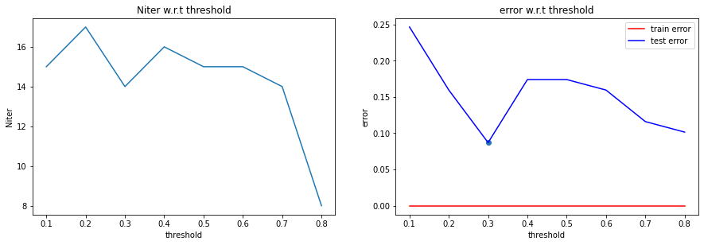

```
We have minimum error when the threshold = 0.30000000000000004
```

```python
plt.figure(figsize=(15, 10),facecolor="white")
plt.subplot(2, 2, 1)
plt.plot(threshold_list, Niter_list)
plt.xlabel("threshold");
plt.ylabel("Niter")
plt.title("Niter w.r.t threshold")
plt.subplot(2, 2, 2)
plt.plot(threshold_list,train_error_list, "r", label="train error")
plt.plot(threshold_list,test_error_list, "b", label="test error")
plt.scatter(threshold_list[test_error_list.index(min(test_error_list))], test_error_list[test_error_list.index(min(test_error_list))])
plt.xlabel("threshold");
plt.ylabel("error")
plt.title("error w.r.t threshold")
plt.legend()
plt.show()
print(f"We have minimum error when the threshold = {threshold_list[test_error_list.index(min(test_error_list))]}")
```

```python
list_sig = np.where(std > 0.7)[0]
x_train = x_train_brut[:, list_sig]
x_test = x_test_brut[:, list_sig]
X_train = np.hstack((np.ones((N_train,1)),x_train))
X_test = np.hstack((np.ones((x_test.shape[0],1)),x_test))
w, Niter = regression_logistique_not_inv_R(X_train, class_train, 20, 1e-3, out=True)
y_pred_test = decision(X_test, w)
print("new error on test set: ", round(error(y_pred_test, class_test), 4))
```

```
 R is not inversible after 12
new error on test set:  0.0811
```

```python
def regression_logistique_regularized(X,t,Nitermax=20,eps_conv=1e-3, Lambda = 1e-5):
    '''Entrees :
    X = [ones(N_train,1) x_train];
    t = class_train
    Nitermax = nombre maximale d'itérations (20 par défaut)
    eps_conv = critère de convergence sur norm(w-w_old)/norm(w) ;
    eps_conv=1e-3 par défaut
    Lambda = 1e-5 facteur de régularisation

    Sorties :
    w : vecteur des coefficients de régression logistique
   Niter : nombre d'itérations utilisées effectivement

   Fonction de régression logistique pour la classification binaire.

   Utilisation :
       Nitermax = 50
       eps_conv = 1e-4
       Lambda = 1e-5
       [w,Niter] = regression_logistique(X,t,Nitermax,eps_conv)
    '''
    N_train = X.shape[0]

    #initialisation : 1 pas de l'algorithme IRLS
    w = np.zeros((X.shape[1],))
    w_old = w
    y = 1/2*np.ones((N_train,))
    R = np.diag(y*(1-y)) + Lambda*np.identity(len(y)) # diag(y_n(1-y_n))
    z = X.dot(w_old)-la.inv(R).dot(y-t)

    w = la.inv(X.T.dot(R).dot(X)).dot(X.T).dot(R).dot(z)

    # boucle appliquant l'algortihme de Newton-Raphson
    Niter = 1
    while ( (la.norm(w-w_old)/la.norm(w)>eps_conv) | (Niter<Nitermax) ):
        Niter = Niter+1
        y = 1/(1+np.exp(-X.dot(w)))
        R = np.diag(y*(1-y))
        w_old = w
        inv_R = la.inv(R+2*Lambda*np.eye(R.shape[0]))
        z = X.dot(w_old)-inv_R .dot(y-t)
        w = la.inv(X.T.dot(R).dot(X)).dot(X.T).dot(R).dot(z)

    return w, Niter
```

```python
X_train_t, X_val, class_train_t, class_val = train_test_split(X_train, class_train, test_size=0.2)
pred_lambda = lambda l: error(decision(X_train_t, regression_logistique_regularized(X_train_t, class_train_t, 20, 1e-3, Lambda=l)[0]), class_train_t)
pred_lambda_val = lambda l: error(decision(X_val, regression_logistique_regularized(X_train_t, class_train_t, 20, 1e-3, Lambda=l)[0]), class_val)

lambda_list = np.logspace(-8, 2, 10)
lambda_train_error = list(map(pred_lambda, lambda_list))
lambda_val_error = list(map(pred_lambda_val, lambda_list))
```

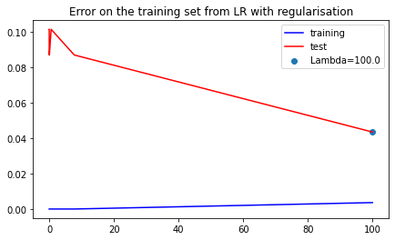

```python
plt.figure(figsize=(7, 4), facecolor="white")
plt.plot(lambda_list, lambda_train_error, color="b", label="training")
plt.plot(lambda_list, lambda_val_error, color="r", label="test")
plt.scatter(lambda_list[np.argmin(lambda_val_error)], lambda_val_error[np.argmin(lambda_val_error)], label=f"Lambda={lambda_list[np.argmin(lambda_val_error)]}")
plt.legend()
plt.title("Error on the training set from LR with regularisation")
plt.show()
```

```python
w_lambda, N_iter = regression_logistique_regularized(X_train, class_train, 20, 1e-3, Lambda=100)
pred_test_lambda = decision(X_test, w_lambda)
print("error with regularization on the test set: ", error(pred_test_lambda, class_test))
```

```
error with regularization on the test set:  0.05942857142857143
```

### Interpreting the model

The advantage of the logistic regression is that it enables an easy interpretation of the behavious as we can obtain the weights of each features and figure out the respective importance. Here we vizualize the pixels that contributed the most to the classification process:

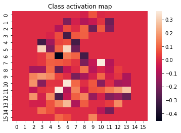

```python
Importance = np.zeros(x_train_brut.shape[1])
Importance[list_sig] = w_lambda[1:]
Importance = Importance.reshape((16, 16))
plt.figure(facecolor="white")
sns.heatmap(Importance)
plt.title("Class activation map")
plt.show()
```

We can see that the edges play a big role in distinguishing the numbers, as well as the center of the number which distinguishes a 5 from a 6. We can also notice that a lot of information is used and it might not be beneficial from the model (noise or irrelevant features) and that could also be a sign of overfitting.

## 3. Logistic regression using `scikit-learn`

1. **Go to** http://scikit-learn.org/stable/modules/generated/sklearn.linear_model.LogisticRegression.html for a presentation of the logistic regression model in `scikit-learn`.
2. **Apply** it to the present data set.
3. **Comment** on the use of logistic regression.

*Indication : you may have a look at*

a) Theory : http://openclassroom.stanford.edu/MainFolder/DocumentPage.php?course=MachineLearning&doc=exercises/ex5/ex5.html

b) Video : https://www.coursera.org/learn/machine-learning/lecture/4BHEy/regularized-logistic-regression

c) Example : http://scikit-learn.org/stable/auto_examples/exercises/plot_digits_classification_exercise.html#sphx-glr-auto-examples-exercises-plot-digits-classification-exercise-py

*for a short presentation of regularized logistic regression.*

We will train our logistic regression model on the x_train without the ones, as the sk-learn does it automatically (fit_intercept is set to True by default and the default value of intercept scaling is 1)

```python
from sklearn.linear_model import LogisticRegression
logisticRegr = LogisticRegression()
logisticRegr.fit(x_train, class_train)

predictions = logisticRegr.predict(x_test)
score = logisticRegr.score(x_test, class_test)
```

The sci-kit learn library offers multiple solvers for the optimization problem. We will test the quasi newton method lbfgs [2] and the liblinear (a linear descient along coordinate directions) [3]. The Quasi-Newton method uses the same algorithm as the New gradient descent without having to calculate the hessian matrix as it approximates it. It is the default solver in the newer version of sk-learn

Since the `lbfgs` doesn't implement the l1 penalty, we first saw which solver work best before comparing l1 and l2. We also tune the model on its regularization parameter C with a cross validation with stratified 10 folds with shuffling the data:

```python
from sklearn.model_selection import GridSearchCV, StratifiedKFold
params = {"C": np.linspace(0.01, 100), "solver":["liblinear", "lbfgs"]}
lr = LogisticRegression()
grid = GridSearchCV(lr, param_grid=params ,cv=StratifiedKFold(n_splits=10, shuffle=True, random_state=10))
grid.fit(x_train, class_train)
print(f"best parameters: {grid.best_params_} and best score (error): {1 - grid.best_score_}")
```

```
best parameters: {'C': 2.050612244897959, 'solver': 'liblinear'} and best score (error): 0.04050420168067226
```

```python
params = {"penalty": ["l1", "l2"]}
lr = LogisticRegression(C=2.051, solver="liblinear")
grid = GridSearchCV(lr, param_grid=params ,cv=StratifiedKFold(n_splits=10, shuffle=True, random_state=10))
grid.fit(x_train, class_train)
print(f"best parameters: {grid.best_params_} and best score (error): {1 - grid.best_score_}")
```

```
best parameters: {'penalty': 'l1'} and best score (error): 0.03756302521008403
```

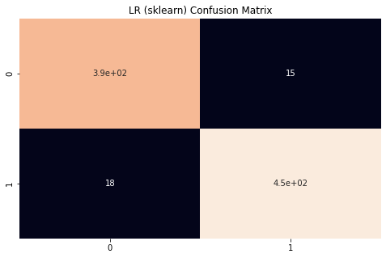

```python
best_lr = grid.best_estimator_
lr.fit(x_train, class_train)
predictions = lr.predict(x_test)
cm = confusion_matrix(predictions, class_test)
tn, fp, fn, tp = cm.ravel()
plt.figure(figsize=(8, 5), facecolor='white')
plt.title("LR (sklearn) Confusion Matrix")
sns.heatmap(cm, annot=True, cbar=False)
plt.show()
```

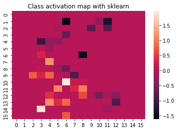

```python
Importance = np.zeros(x_train_brut.shape[1])
Importance[list_sig] = best_lr.coef_[0]
Importance = Importance.reshape((16, 16))
plt.figure(facecolor="white")
sns.heatmap(Importance)
plt.title("Class activation map with sklearn")
plt.show()
```

Commentaires :

In their documentation, liblinear works better for small datasets which is our case (around 300 samples) and the l1 penalty was better which disproves our claim earlier. However, it could be that this penalty is better for this optimization algorithm, and might not work as well for others.

This algorithm was able to classify well images in less than 0.1s and without calculation accelerators (like GPU). Usually in this task, the first model we use is a deep learning CNN model which needs a lot more samples to estimate its parameters, and it needs a lot more time to fit to the training data. Our approach should be to first look at the data available, and try simple and interpretable models like the logistic regression before going to more complicated ones.

Sources

[1] Robust Linear Discriminant Analysis Sharipah Soaad Syed Yahaya, Yai-Fung Lim, Hazlina Ali and Zurni Omar. https://thescipub.com/pdf/jmssp.2016.312.316.pdf

[2] L-BFGS-B – Software for Large-scale Bound-constrained Optimization Ciyou Zhu, Richard Byrd, Jorge Nocedal and Jose Luis Morales. http://users.iems.northwestern.edu/~nocedal/lbfgsb.html

[3] LIBLINEAR – A Library for Large Linear Classification https://www.csie.ntu.edu.tw/~cjlin/liblinear/

[4] Cao, Chang et al. “The MCC-F1 curve: a performance evaluation technique for binary classification.” ArXiv abs/2006.11278 (2020): n. pag.

[5] https://scikit-learn.org/stable/auto_examples/classification/plot_lda_qda.html?fbclid=IwAR0-V8Q5nEopZIpd2hpT-W6yVlXpOxoTAmy9CKoJbVvjSE-GDaVyWYQAts4

```python
%%javascript
IPython.notebook.save_notebook()
```

```python
import os

os.system('jupyter nbconvert --to html TP2_MAKHLOUF_MAKNI.ipynb')
```

```
-1
```